# Session 3 — Random-Intercept (Mixed) Models

Variance components · adjusted ICC · BLUPs and shrinkage · conditional vs marginal · Lab 3

Community Medicine Workshop

## Where we are

- Session 2: keep an ordinary model and **repair the SE**
- Today: **model the clustering** with a **random intercept** for village
- By the end you can:
  - fit and read a **linear mixed model** with `lmer`
  - read **variance components** and the **adjusted ICC**
  - explain **shrinkage** of village estimates
  - contrast **conditional** and **marginal** effects

# Topic 1 — The model

## A random intercept for each village

SBP<sub>ij</sub> = β<sub>0</sub> + β<sub>1</sub> Programme<sub>j</sub> + β<sub>2</sub> Age<sub>ij</sub> + … + **u<sub>j</sub>** + ε<sub>ij</sub> u<sub>j</sub> ~ N(0, τ²), ε<sub>ij</sub> ~ N(0, σ²)

- **Fixed effects** β: the average relationship (the programme effect)
- **Random intercept** u<sub>j</sub>: each village has its own shift, **drawn from a normal distribution**
- τ² = **between-village** variance, σ² = **within-village** variance
- ICC = **τ² / (τ² + σ²)**

## Fit it

```r
m1 <- lmer(sbp ~ arm + age + sex + bmi + (1 | village), data = bp12)
summary(m1)$coefficients |> round(3)
```

```
             Estimate Std. Error      df t value Pr(>|t|)
(Intercept)   105.469      4.503 638.117  23.423    0.000
armProgramme   -3.565      1.602  39.036  -2.226    0.032
age             0.257      0.054 645.709   4.756    0.000
sexMale         3.014      1.131 639.770   2.665    0.008
bmi             0.363      0.145 641.818   2.506    0.012
```

The programme effect is **−3.6 mmHg** (SE **1.6**), with **Satterthwaite degrees of freedom of about 39** from `lmerTest`. `(1 | village)` means *a separate intercept for each village*.

## Variance components and ICC

```r
VarCorr(m1)
```

```
 Groups   Name        Std.Dev.
 village  (Intercept)  3.6172
 Residual             14.2415
```

```r
icc(m1)
```

```
# Intraclass Correlation Coefficient

    Adjusted ICC: 0.061
  Unadjusted ICC: 0.056
```

- Village SD **3.6** mmHg, residual SD **14.2** mmHg
- **Adjusted ICC ≈ 0.06**: after accounting for age, sex, BMI and arm
- Adjusted and unadjusted ICC differ because covariates explain part of the variance

## Is the village effect needed?

```r
ranova(m1)
```

```
ANOVA-like table for random-effects: Single term deletions

Model:
sbp ~ arm + age + sex + bmi + (1 | village)
              npar  logLik    AIC   LRT Df Pr(>Chisq)
<none>           7 -2689.2 5392.3
(1 | village)    6 -2695.2 5402.4 12.08  1  0.0005097 ***
---
Signif. codes:  0 '***' 0.001 '**' 0.01 '*' 0.05 '.' 0.1 ' ' 1
```

- A **likelihood-ratio** test of the random intercept: p ≈ **0.0005**
- The test is on the **boundary** (τ² cannot be negative), so the p-value is conservative
- **Do not drop** the cluster effect because the ICC is small or the test is not significant: the **design** says the data are clustered

# Topic 2 — Shrinkage

## Predicted village effects (BLUPs)

```r
tibble(village = rownames(ranef(m1)$village), re = ranef(m1)$village[, 1]) |> arrange(re) |> mutate(village = fct_inorder(village)) |>
  ggplot(aes(re, village)) + geom_point(colour = col_blue, size = 2.5) + geom_vline(xintercept = 0, linetype = 2) +
  labs(x = "Predicted village shift (mmHg)", y = "Village") + theme(axis.text.y = element_blank())
```

Shifts range from about **−5 to +6 mmHg**. They are **predictions** (BLUPs), not parameters.

## Predicted village effects (BLUPs)

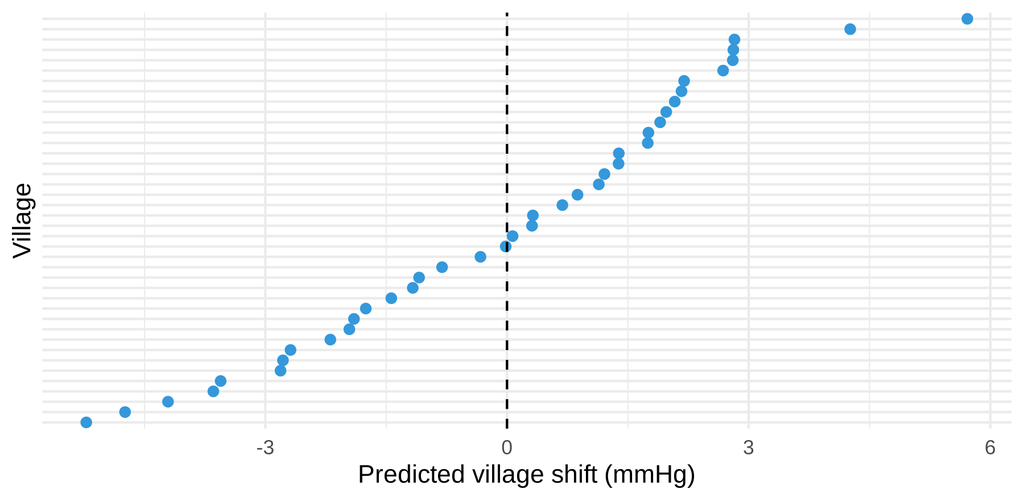

## Shrinkage

û<sub>j</sub> = [ τ² / (τ² + σ²/n<sub>j</sub>) ] × (village mean − overall mean)

- The factor is **between 0 and 1**: village estimates are **pulled towards the overall mean**
- **Small** villages and **noisy** data are pulled **more**; large, precise villages less
- Good for ranking or flagging villages: extremes by chance are **moderated**

# Topic 3 — Comparing approaches

## Same effect, three standard errors

```r
rbind(naive = summary(m_lm <- lm(sbp ~ arm + age + sex + bmi, data = bp12))$coefficients["armProgramme", 1:2],
      cluster_robust = coeftest(m_lm, vcov = vcovCL(m_lm, cluster = bp12$village))["armProgramme", 1:2],
      mixed = summary(m1)$coefficients["armProgramme", 1:2]) |> round(2)
```

```
               Estimate Std. Error
naive             -3.42       1.15
cluster_robust    -3.42       1.59
mixed             -3.57       1.60
```

The **naive** SE is too small. The **cluster-robust** and **mixed-model** SEs agree. For a linear model with an identity link, the **conditional** and **marginal** effects are the **same**.

## Conditional or marginal?

|  | Mixed model | GEE / robust |
| --- | --- | --- |
| Effect | **Conditional**: same village | **Marginal**: average over villages |
| Linear outcome | same number | same number |
| Logistic outcome | **larger** odds ratio (further from 1) | smaller OR |
| Also gives | village predictions, variance components | no cluster-level estimates |
| Missing data | valid under MAR | needs more care |

## Reporting a mixed model

- State the **model**: fixed effects, the **random effect** and the **estimation** (REML)
- Report the **effect with CI**, and say how the **df** were obtained
- Report the **ICC** (adjusted) or the variance components
- Say whether the effect is **conditional**

## 🔧 Switch to R — Lab 3

**File:** `clustered-workshop/labs/lab3_mixed.R`

- `lmer` with `(1 | village)`
- variance components, ICC, `ranova`
- BLUPs, a caterpillar plot and a comparison of SEs

**Time:** 40 minutes · answer the Q questions in the comments

## Self-check quiz (1/5)

In a model with (1 | village), what is the random intercept?

- A shift in mean SBP for each village, assumed to follow a normal distribution
- A separate fixed effect estimated for each of the forty villages in the study
- The average SBP of the villages that were given the programme
- The residual error of each adult measured within the study sample

## Self-check quiz (2/5)

The village SD is 3.6 and the residual SD is 14.2. Which expression gives the ICC?

- (3.6 + 14.2)^2 / 3.6^2
- 3.6^2 / (3.6^2 + 14.2^2)
- 3.6 / (3.6 + 14.2)^2
- 14.2^2 / (3.6^2 + 14.2^2)

## Self-check quiz (3/5)

What does shrinkage do to a village’s predicted effect?

- It moves the estimate further from the mean, which is stronger for small villages
- It sets the village estimate to zero when the village has few adults in it
- It drops from the model villages that have fewer than ten adults in them
- It pulls the estimate towards the overall mean, more so for small villages

## Self-check quiz (4/5)

An ICC of 0.02 is found in a cluster-randomised trial with 50 per cluster. What is the best action?

- Keep the cluster in the analysis, since the design makes data clustered
- Drop the cluster effect from the model, because an ICC this small is negligible
- Drop the cluster effect once the ICC is shown to fall under a cut-off of 0.05
- Replace the cluster by a fixed effect for each person in the whole trial

## Self-check quiz (5/5)

For a continuous outcome, how do the mixed model and cluster-robust lm effects compare?

- The mixed model effect is about twice as large as the robust one
- The cluster-robust SE is clearly smaller than the mixed model SE
- The estimates are close and the standard errors are similar
- They estimate different quantities and cannot be put side by side

## Score and take-home

**Your score:**

- **Random intercept** (1 | village): a normal shift per cluster
- **ICC = τ² / (τ² + σ²)**; the adjusted ICC uses the model’s variances
- **BLUPs** are shrunk towards the mean
- Keep the cluster effect because of the **design**
- Linear model: conditional = marginal; not for logistic

**Next:** Session 4: repeated measures